# Building a Naive Bayes Model Workflow

1. Introduction
2. Step 1: Imports
3. Step 2: Model Preparation
4. Step 3: Model Building
5. Step 4: Results and Evaluation
6. Considerations

[figure not shown]

# Introduction

> - In this project, I will build my own Naive Bayes model. Naive Bayes models can be valuable to use any time a data professional is doing work with predictions because Naive Bayes models give data professionals a way to account for new information.
> - For this project, I work for a firm that provides insights for management and coaches in the National Basketball Association (NBA), a professional basketball league in North America. The league is interested in retaining players who can last in the high-pressure environment of professional basketball and help the team be successful over time.
> - Previously, I analyzed a subset of data that contained information about the NBA players and their performance records. I conducted feature engineering to determine which features would most effectively predict a player's career duration. I will now use those insights to build a model to make a prediction.

[figure not shown]

**The Purpose**:

> - To demostrate an active and working knowledge of applying a Naive Bayes model or supervised machine learning to an existing dataset to make a prediction.

**The Goal**:

> - Use data insights to build a model that predicts whether a player will have an NBA career lasting five years or more.

# Step 1: Imports

```python
# Importing relevant libraries and modules.
import pandas as pd
from sklearn import naive_bayes
from sklearn import model_selection
from sklearn import metrics
```

```python
# Loading extracted_nba_players_data.csv into a dataFrame called extracted_data.
extracted_data = pd.read_csv('extracted_nba_players_data.csv')
```

```python
# Displaying the first 10 rows of the dataset
extracted_data.head(10)
```

|  | fg | 3p | ft | reb | ast | stl | blk | tov | target_5yrs | total_points | efficiency |
| --- | --- | --- | --- | --- | --- | --- | --- | --- | --- | --- | --- |
| 0 | 34.7 | 25.0 | 69.9 | 4.1 | 1.9 | 0.4 | 0.4 | 1.3 | 0 | 266.4 | 0.270073 |
| 1 | 29.6 | 23.5 | 76.5 | 2.4 | 3.7 | 1.1 | 0.5 | 1.6 | 0 | 252.0 | 0.267658 |
| 2 | 42.2 | 24.4 | 67.0 | 2.2 | 1.0 | 0.5 | 0.3 | 1.0 | 0 | 384.8 | 0.339869 |
| 3 | 42.6 | 22.6 | 68.9 | 1.9 | 0.8 | 0.6 | 0.1 | 1.0 | 1 | 330.6 | 0.491379 |
| 4 | 52.4 | 0.0 | 67.4 | 2.5 | 0.3 | 0.3 | 0.4 | 0.8 | 1 | 216.0 | 0.391304 |
| 5 | 42.3 | 32.5 | 73.2 | 0.8 | 1.8 | 0.4 | 0.0 | 0.7 | 0 | 277.5 | 0.324561 |
| 6 | 43.5 | 50.0 | 81.1 | 2.0 | 0.6 | 0.2 | 0.1 | 0.7 | 1 | 409.2 | 0.605505 |
| 7 | 41.5 | 30.0 | 87.5 | 1.7 | 0.2 | 0.2 | 0.1 | 0.7 | 1 | 273.6 | 0.553398 |
| 8 | 39.2 | 23.3 | 71.4 | 0.8 | 2.3 | 0.3 | 0.0 | 1.1 | 0 | 156.0 | 0.242424 |
| 9 | 38.3 | 21.4 | 67.8 | 1.1 | 0.3 | 0.2 | 0.0 | 0.7 | 0 | 155.4 | 0.435294 |

# Step 2: Model Preparation

### Isolating the target and predictor variables

```python
# Defining the y (target) variable.
y = extracted_data['target_5yrs']

# Defining the X (predictor) variables.
X = extracted_data.drop('target_5yrs', axis = 1)
```

```python
# Displaying the first 10 rows of the target data.
y.head(10)
```

```
0    0
1    0
2    0
3    1
4    1
5    0
6    1
7    1
8    0
9    0
Name: target_5yrs, dtype: int64
```

```python
# Displaying the first 10 rows of the predictor variables.
X.head(10)
```

|  | fg | 3p | ft | reb | ast | stl | blk | tov | total_points | efficiency |
| --- | --- | --- | --- | --- | --- | --- | --- | --- | --- | --- |
| 0 | 34.7 | 25.0 | 69.9 | 4.1 | 1.9 | 0.4 | 0.4 | 1.3 | 266.4 | 0.270073 |
| 1 | 29.6 | 23.5 | 76.5 | 2.4 | 3.7 | 1.1 | 0.5 | 1.6 | 252.0 | 0.267658 |
| 2 | 42.2 | 24.4 | 67.0 | 2.2 | 1.0 | 0.5 | 0.3 | 1.0 | 384.8 | 0.339869 |
| 3 | 42.6 | 22.6 | 68.9 | 1.9 | 0.8 | 0.6 | 0.1 | 1.0 | 330.6 | 0.491379 |
| 4 | 52.4 | 0.0 | 67.4 | 2.5 | 0.3 | 0.3 | 0.4 | 0.8 | 216.0 | 0.391304 |
| 5 | 42.3 | 32.5 | 73.2 | 0.8 | 1.8 | 0.4 | 0.0 | 0.7 | 277.5 | 0.324561 |
| 6 | 43.5 | 50.0 | 81.1 | 2.0 | 0.6 | 0.2 | 0.1 | 0.7 | 409.2 | 0.605505 |
| 7 | 41.5 | 30.0 | 87.5 | 1.7 | 0.2 | 0.2 | 0.1 | 0.7 | 273.6 | 0.553398 |
| 8 | 39.2 | 23.3 | 71.4 | 0.8 | 2.3 | 0.3 | 0.0 | 1.1 | 156.0 | 0.242424 |
| 9 | 38.3 | 21.4 | 67.8 | 1.1 | 0.3 | 0.2 | 0.0 | 0.7 | 155.4 | 0.435294 |

**Observation**:

> - The data indicates that all of the predictor variables are continuous numerical values, so it is important that the model I select be suitable for continuous features.

### Performing a split on the dataset

> - I'll start by Dividing the data into a training set (`75% of data`) and test set (`25% of data`). This is an important step in the process, as it allows me to reserve a part of the data that the model has not observed. This tests how well the model generalizes—or performs—on new data.

```python
# Performing the split operation on the dataset
# Assigning the outputs as follows: X_train, X_test, y_train, y_test.
X_train, X_test, y_train, y_test = model_selection.train_test_split(X, y, test_size=0.25, random_state=0)
```

### Printing the shape of each output

> - By printing the shape of each output from the train-test split, this will verify that the split operated as expected.

```python
# Printing the shape of X_train.
print(X_train.shape)

# Printing the shape of X_test.
print(X_test.shape)

# Printing the shape of y_train.
print(y_train.shape)

# Printing the shape of y_test.
print(y_test.shape)
```

```
(1005, 10)
(335, 10)
(1005,)
(335,)
```

**Observations**:

> - Each training DataFrame contains 1,005 rows, while each test DataFrame contains 335 rows. Additionally, there are 10 columns in each X DataFrame, with only one column in each y DataFrame.
> - The effect of the train-test split showed an approximately `75%` training and `25%` test split.

# Step 3: Model Building

### Evaluating which Naive Bayes algorithm to use on this dataset

> - Using the assumption that the features of this dataset are normally distributed and continuous, the Gaussian Naive Bayes algorithm is most appropriate for this data. While the data may not perfectly adhere to these assumptions, this model will still yield the most usable and accurate results.

### Fitting the model to the training data and predict on the test data

> - By creating this model, I will be drawing on my feature engineering work by training the classifier on the `X_train` DataFrame. I will use this to predict `target_5yrs` from `y_train`.
> - I'll start by defining `nb` to be the relevant algorithm from `sklearn.naive_bayes`. Then fit the model to the training data. I'll then use this fitted model to create predictions for the test data.

```python
# Assigning `nb` to be the appropriate implementation of Naive Bayes.
nb = naive_bayes.GaussianNB()

# Fitting the model on the training data.
nb.fit(X_train, y_train)

# Applying the model to predict on the test data. I'll call this "y_pred".
y_pred = nb.predict(X_test)
```

# Step 4: Results and Evaluation

### Leveraging metrics to evaluate the model's performance

> - To evaluate the data yielded from this model, I can leverage a series of metrics and evaluation techniques from scikit-learn by examining the actual observed values in the test set relative to the model's prediction.

```python
# Printing the accuracy score.
print('accuracy score:'), print(metrics.accuracy_score(y_test, y_pred))

# Printing the precision score.
print('precision score:'), print(metrics.precision_score(y_test, y_pred))

# Printing the recall score.
print('recall score:'), print(metrics.recall_score(y_test, y_pred))

# Printing the f1 score.
print('f1 score:'), print(metrics.f1_score(y_test, y_pred))
```

```
accuracy score:
0.6895522388059702
precision score:
0.8405797101449275
recall score:
0.5858585858585859
f1 score:
0.6904761904761905
```

```
(None, None)
```

### Gaining clarity with the confusion matrix

> - A confusion matrix is a graphic that shows a model's true and false positives and negatives. It helps to create a visual representation of the components feeding into the metrics.

```
<sklearn.metrics._plot.confusion_matrix.ConfusionMatrixDisplay at 0x1e498d94d00>
```

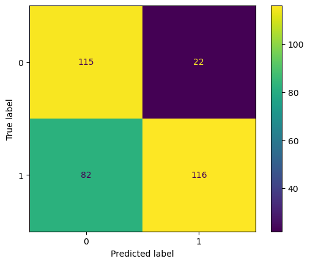

```python
# Constructing the confusion matrix for the predicted and test values.
cm = metrics.confusion_matrix(y_test, y_pred)

# Creating the display for the confusion matrix.
disp = metrics.ConfusionMatrixDisplay(confusion_matrix=cm, display_labels=nb.classes_)

# Plotting the visual in-line.
disp.plot()
```

# Considerations

**Takeaways**:

> - Evaluation of the model is important to inform if the model has delivered accurate predictions.
> - Splitting the data was important for ensuring that there was new data for the model to test its predictive performance.
> - Each metric provided an evaluation from a different standpoint, and accuracy alone was not a strong way to evaluate the model.
> - Effective assessments balance the true/false positives versus true/false negatives through the confusion matrix and F1 score.

**How I would present results to the team**:

> - Showcase the data used to create the prediction and the performance of the model overall.
> - Review the sample output of the features and the confusion matrix to indicate the model's performance.
> - Highlight the metric values, emphasizing the F1 score.